# Predicting Target_Deathrate from cancer dataset

Importing Libraries and Reading the Dataset (Cancer.csv) and then checking the dataset

```python
import pandas as pd ##importing various libraries
from sklearn.model_selection import KFold##validation
from sklearn.pipeline import Pipeline
from sklearn.preprocessing import StandardScaler
from sklearn.preprocessing import PolynomialFeatures
from sklearn.linear_model import LinearRegression##Model selected
from sklearn.model_selection import train_test_split
import matplotlib.pyplot as plt
import seaborn as sb
import statsmodels.api as sm
import numpy as np

df = pd.read_csv("cancer.csv", encoding="ISO-8859-1")##Apple and windows issue encoding was used
df = df.reset_index()


df.head()
```

|  | index | avgAnnCount | avgDeathsPerYear | TARGET_deathRate | incidenceRate | medIncome | popEst2015 | povertyPercent | studyPerCap | binnedInc | ... | PctPrivateCoverageAlone | PctEmpPrivCoverage | PctPublicCoverage | PctPublicCoverageAlone | PctWhite | PctBlack | PctAsian | PctOtherRace | PctMarriedHouseholds | BirthRate |
| --- | --- | --- | --- | --- | --- | --- | --- | --- | --- | --- | --- | --- | --- | --- | --- | --- | --- | --- | --- | --- | --- |
| 0 | 0 | 1397.0 | 469 | 164.9 | 489.8 | 61898 | 260131 | 11.2 | 499.748204 | (61494.5, 125635] | ... | NaN | 41.6 | 32.9 | 14.0 | 81.780529 | 2.594728 | 4.821857 | 1.843479 | 52.856076 | 6.118831 |
| 1 | 1 | 173.0 | 70 | 161.3 | 411.6 | 48127 | 43269 | 18.6 | 23.111234 | (48021.6, 51046.4] | ... | 53.8 | 43.6 | 31.1 | 15.3 | 89.228509 | 0.969102 | 2.246233 | 3.741352 | 45.372500 | 4.333096 |
| 2 | 2 | 102.0 | 50 | 174.7 | 349.7 | 49348 | 21026 | 14.6 | 47.560164 | (48021.6, 51046.4] | ... | 43.5 | 34.9 | 42.1 | 21.1 | 90.922190 | 0.739673 | 0.465898 | 2.747358 | 54.444868 | 3.729488 |
| 3 | 3 | 427.0 | 202 | 194.8 | 430.4 | 44243 | 75882 | 17.1 | 342.637253 | (42724.4, 45201] | ... | 40.3 | 35.0 | 45.3 | 25.0 | 91.744686 | 0.782626 | 1.161359 | 1.362643 | 51.021514 | 4.603841 |
| 4 | 4 | 57.0 | 26 | 144.4 | 350.1 | 49955 | 10321 | 12.5 | 0.000000 | (48021.6, 51046.4] | ... | 43.9 | 35.1 | 44.0 | 22.7 | 94.104024 | 0.270192 | 0.665830 | 0.492135 | 54.027460 | 6.796657 |

5 rows × 35 columns

checking numbers of columns and rows in dataset by using shape and checking datatypes

```python
df.shape
df.dtypes
```

```
index                        int64
avgAnnCount                float64
avgDeathsPerYear             int64
TARGET_deathRate           float64
incidenceRate              float64
medIncome                    int64
popEst2015                   int64
povertyPercent             float64
studyPerCap                float64
binnedInc                   object
MedianAge                  float64
MedianAgeMale              float64
MedianAgeFemale            float64
Geography                   object
AvgHouseholdSize           float64
PercentMarried             float64
PctNoHS18_24               float64
PctHS18_24                 float64
PctSomeCol18_24            float64
PctBachDeg18_24            float64
PctHS25_Over               float64
PctBachDeg25_Over          float64
PctEmployed16_Over         float64
PctUnemployed16_Over       float64
PctPrivateCoverage         float64
PctPrivateCoverageAlone    float64
PctEmpPrivCoverage         float64
PctPublicCoverage          float64
PctPublicCoverageAlone     float64
PctWhite                   float64
PctBlack                   float64
PctAsian                   float64
PctOtherRace               float64
PctMarriedHouseholds       float64
BirthRate                  float64
dtype: object
```

Dataset has mainly float datatype - need to change all datatype to float - below changing datatype to float and then checking datatype again -medIncome/popEst2015/binnedInc/Geography/index- need to change to float

```python
cols = df.select_dtypes(exclude=['float']).columns
df[cols] = df[cols].apply(pd.to_numeric, downcast='float', errors='coerce')
df.dtypes
```

```
index                      float32
avgAnnCount                float64
avgDeathsPerYear           float32
TARGET_deathRate           float64
incidenceRate              float64
medIncome                  float32
popEst2015                 float32
povertyPercent             float64
studyPerCap                float64
binnedInc                  float32
MedianAge                  float64
MedianAgeMale              float64
MedianAgeFemale            float64
Geography                  float32
AvgHouseholdSize           float64
PercentMarried             float64
PctNoHS18_24               float64
PctHS18_24                 float64
PctSomeCol18_24            float64
PctBachDeg18_24            float64
PctHS25_Over               float64
PctBachDeg25_Over          float64
PctEmployed16_Over         float64
PctUnemployed16_Over       float64
PctPrivateCoverage         float64
PctPrivateCoverageAlone    float64
PctEmpPrivCoverage         float64
PctPublicCoverage          float64
PctPublicCoverageAlone     float64
PctWhite                   float64
PctBlack                   float64
PctAsian                   float64
PctOtherRace               float64
PctMarriedHouseholds       float64
BirthRate                  float64
dtype: object
```

We cannot have Null/Nan/empty values in the database - next is to check how many nan values we have

```python
df.isna().sum()
```

```
index                         0
avgAnnCount                   0
avgDeathsPerYear              0
TARGET_deathRate              0
incidenceRate                 0
medIncome                     0
popEst2015                    0
povertyPercent                0
studyPerCap                   0
binnedInc                  3047
MedianAge                     0
MedianAgeMale                 0
MedianAgeFemale               0
Geography                  3047
AvgHouseholdSize              0
PercentMarried                0
PctNoHS18_24                  0
PctHS18_24                    0
PctSomeCol18_24            2285
PctBachDeg18_24               0
PctHS25_Over                  0
PctBachDeg25_Over             0
PctEmployed16_Over          152
PctUnemployed16_Over          0
PctPrivateCoverage            0
PctPrivateCoverageAlone     609
PctEmpPrivCoverage            0
PctPublicCoverage             0
PctPublicCoverageAlone        0
PctWhite                      0
PctBlack                      0
PctAsian                      0
PctOtherRace                  0
PctMarriedHouseholds          0
BirthRate                     0
dtype: int64
```

We can see there are few columns with Nan values - will be dropping them- some columns which has too many Nan values I will be adding the columns in a list and then putting them in y and x variable - only Target_deathRate will be in y - in the rest of the code i will be using Fillna() function to fill in the nan values with median of the columns which has nan values

```python
Data = list(['Geography','avgAnnCount','avgDeathsPerYear','incidenceRate','medIncome','popEst2015','povertyPercent','studyPerCap','binnedInc','MedianAge','PctPrivateCoverageAlone','PctEmpPrivCoverage','PctPublicCoverage','PctPublicCoverageAlone','PctWhite','PctBlack','PctAsian','PctOtherRace','PctMarriedHouseholds','BirthRate'])
y = pd.DataFrame(df, columns=["TARGET_deathRate"])
X = pd.DataFrame(df, columns=Data)

df['PctSomeCol18_24']=df['PctSomeCol18_24'].fillna(df['PctSomeCol18_24'].median())
df['PctEmployed16_Over']=df['PctEmployed16_Over'].fillna(df['PctEmployed16_Over'].median())
df['PctPrivateCoverageAlone']=df['PctPrivateCoverageAlone'].fillna(df['PctPrivateCoverageAlone'].median())
df.isna().sum()
```

```
index                         0
avgAnnCount                   0
avgDeathsPerYear              0
TARGET_deathRate              0
incidenceRate                 0
medIncome                     0
popEst2015                    0
povertyPercent                0
studyPerCap                   0
binnedInc                  3047
MedianAge                     0
MedianAgeMale                 0
MedianAgeFemale               0
Geography                  3047
AvgHouseholdSize              0
PercentMarried                0
PctNoHS18_24                  0
PctHS18_24                    0
PctSomeCol18_24               0
PctBachDeg18_24               0
PctHS25_Over                  0
PctBachDeg25_Over             0
PctEmployed16_Over            0
PctUnemployed16_Over          0
PctPrivateCoverage            0
PctPrivateCoverageAlone       0
PctEmpPrivCoverage            0
PctPublicCoverage             0
PctPublicCoverageAlone        0
PctWhite                      0
PctBlack                      0
PctAsian                      0
PctOtherRace                  0
PctMarriedHouseholds          0
BirthRate                     0
dtype: int64
```

We have 2 columns still with Nan values as the number of nan is large - to keep with consistent i will be using drop() function to remove these columns and i dont need the Target_deathRate variable in the X list. and need to check and remove dupicate data

```python
X = df.drop(['Geography','binnedInc','TARGET_deathRate'],axis=1)##dropping columns
df.drop_duplicates()##removing duplicated data
X.isna().sum()
```

```
index                      0
avgAnnCount                0
avgDeathsPerYear           0
incidenceRate              0
medIncome                  0
popEst2015                 0
povertyPercent             0
studyPerCap                0
MedianAge                  0
MedianAgeMale              0
MedianAgeFemale            0
AvgHouseholdSize           0
PercentMarried             0
PctNoHS18_24               0
PctHS18_24                 0
PctSomeCol18_24            0
PctBachDeg18_24            0
PctHS25_Over               0
PctBachDeg25_Over          0
PctEmployed16_Over         0
PctUnemployed16_Over       0
PctPrivateCoverage         0
PctPrivateCoverageAlone    0
PctEmpPrivCoverage         0
PctPublicCoverage          0
PctPublicCoverageAlone     0
PctWhite                   0
PctBlack                   0
PctAsian                   0
PctOtherRace               0
PctMarriedHouseholds       0
BirthRate                  0
dtype: int64
```

```python
X.iloc[1:10,7:]
```

|  | studyPerCap | MedianAge | MedianAgeMale | MedianAgeFemale | AvgHouseholdSize | PercentMarried | PctNoHS18_24 | PctHS18_24 | PctSomeCol18_24 | PctBachDeg18_24 | ... | PctPrivateCoverageAlone | PctEmpPrivCoverage | PctPublicCoverage | PctPublicCoverageAlone | PctWhite | PctBlack | PctAsian | PctOtherRace | PctMarriedHouseholds | BirthRate |
| --- | --- | --- | --- | --- | --- | --- | --- | --- | --- | --- | --- | --- | --- | --- | --- | --- | --- | --- | --- | --- | --- |
| 1 | 23.111234 | 33.0 | 32.2 | 33.7 | 2.34 | 44.5 | 6.1 | 22.4 | 64.0 | 7.5 | ... | 53.8 | 43.6 | 31.1 | 15.3 | 89.228509 | 0.969102 | 2.246233 | 3.741352 | 45.372500 | 4.333096 |
| 2 | 47.560164 | 45.0 | 44.0 | 45.8 | 2.62 | 54.2 | 24.0 | 36.6 | 40.4 | 9.5 | ... | 43.5 | 34.9 | 42.1 | 21.1 | 90.922190 | 0.739673 | 0.465898 | 2.747358 | 54.444868 | 3.729488 |
| 3 | 342.637253 | 42.8 | 42.2 | 43.4 | 2.52 | 52.7 | 20.2 | 41.2 | 36.1 | 2.5 | ... | 40.3 | 35.0 | 45.3 | 25.0 | 91.744686 | 0.782626 | 1.161359 | 1.362643 | 51.021514 | 4.603841 |
| 4 | 0.000000 | 48.3 | 47.8 | 48.9 | 2.34 | 57.8 | 14.9 | 43.0 | 40.0 | 2.0 | ... | 43.9 | 35.1 | 44.0 | 22.7 | 94.104024 | 0.270192 | 0.665830 | 0.492135 | 54.027460 | 6.796657 |
| 5 | 180.259902 | 45.4 | 43.5 | 48.0 | 2.58 | 50.4 | 29.9 | 35.1 | 40.4 | 4.5 | ... | 38.8 | 32.6 | 43.2 | 20.2 | 84.882631 | 1.653205 | 1.538057 | 3.314635 | 51.220360 | 4.964476 |
| 6 | 0.000000 | 42.6 | 42.2 | 43.5 | 2.42 | 54.1 | 26.1 | 41.4 | 40.4 | 5.8 | ... | 35.0 | 28.3 | 46.4 | 28.7 | 75.106455 | 0.616955 | 0.866157 | 8.356721 | 51.013900 | 4.204317 |
| 7 | 0.000000 | 51.7 | 50.8 | 52.5 | 2.24 | 52.7 | 27.3 | 33.9 | 36.5 | 2.2 | ... | 33.1 | 25.9 | 50.9 | 24.1 | 89.406636 | 0.305159 | 1.889077 | 2.286268 | 48.967033 | 5.889179 |
| 8 | 0.000000 | 49.3 | 48.4 | 49.8 | 2.38 | 55.9 | 34.7 | 39.4 | 40.4 | 1.4 | ... | 37.8 | 29.9 | 48.1 | 26.6 | 91.787477 | 0.185071 | 0.208205 | 0.616903 | 53.446998 | 5.587583 |
| 9 | 427.748432 | 35.8 | 34.7 | 37.0 | 2.65 | 50.0 | 15.6 | 36.3 | 40.4 | 7.1 | ... | 48.7 | 44.4 | 31.4 | 16.5 | 74.729668 | 6.710854 | 6.041472 | 2.699184 | 50.063573 | 5.533430 |

9 rows × 25 columns

The dataset is now cleared from Nan values and all columns coverted to float datatype - now that we have processed - i am going to using KFOLD to split the data into train and test sets. It will split dataset into k consecutive folds (without shuffling by default).Each fold is then used a validation set once while the k - 1 remaining folds form the training set

```python
kf = KFold(n_splits = 5, shuffle=True, random_state=10)
kf.get_n_splits(X)
```

```
5
```

Now that we have the split function KFold , i will be using the function to split the data in to X and Y train and test and then pipeline is used to assemble several steps that can be cross-validated together while setting different parameters. and then working out the score to calculate the accuracy of data

```python
##import numpy as np

# Empty vectors of scores
R2_train = []
R2_test = []

for train_index, test_index in kf.split(X):
    X_train, X_test = X.iloc[train_index,:], X.iloc[test_index, :]
    y_train, y_test = y.iloc[train_index,:], y.iloc[test_index, :]
    ##building a pipeline
    pipe_deg1 = Pipeline([('scaler', StandardScaler()),
                         ('poly', PolynomialFeatures(1)), ##1 is producing better results
                          ('lm', LinearRegression())]) # training a linear regression model

    # using the pipeline
    pipe_deg1.fit(X_train, y_train)

    R2_train.append( pipe_deg1.score(X_train, y_train) )
    R2_test.append( pipe_deg1.score(X_test, y_test) )

    # Use the trained model to create predictions on train and test data
    y_pred = pipe_deg1.predict(X_test)
    y_train_pred = pipe_deg1.predict(X_train)

R2_train_mean = round(np.mean(R2_train), 2)
R2_test_mean = round(np.mean(R2_test), 2)

print("Mean R2 on train:", R2_train_mean )
print("Mean R2 on test:", R2_test_mean )
pipe_deg1.score(X_test,y_test)
```

```
Mean R2 on train: 0.53
Mean R2 on test: 0.5
```

```
0.5083438271620662
```

checking the accuracy of the model -

Test the results with polunialfeatures set to 2 result was 0.76 Mean R2 on train: 0.76 Mean R2 on test: -94.54 Test the results with polunialfeatures set to 3 result was 0.76 Mean R2 on train: 1.0 Mean R2 on test: -45.75

```python
print('Accuracy', 100-(np.mean((np.abs(y_test-y_pred)/y_test))*100)) ##worst accuracy result was 64.33 when setting poly to 3
##best result came from setting it to 1 which is 91.84
```

```
Accuracy TARGET_deathRate    91.843263
dtype: float64
```

Will now be plotting the results

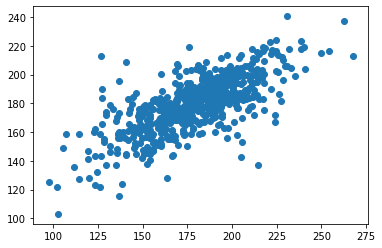

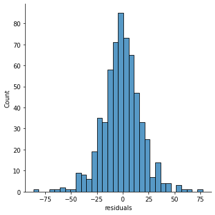

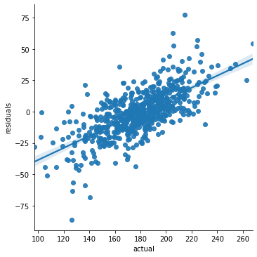

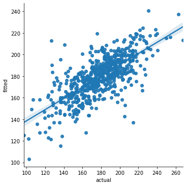

```python
plt.scatter(y_test.values.ravel(),y_pred)
test = pd.DataFrame({'actual': y_test.TARGET_deathRate.values,
                   'fitted': pipe_deg1.predict(X_test).squeeze()})
test["residuals"] = test.actual - test.fitted
test.head()
sb.displot(test, x="residuals")
sb.lmplot(data=test, x="actual", y="residuals", scatter_kws={'alpha':0.9})
sb.lmplot(data=test, x="actual", y="fitted", scatter_kws={'alpha':0.9})
```

checking the results using stats

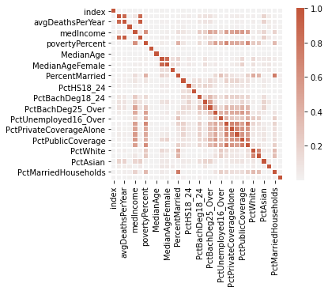

```python
# Generat in diverging map
cmap = sb.diverging_palette(230, 20, as_cmap=True)

sb.heatmap(X.corr()**2, cmap=cmap, center=0, square=True, linewidths=.5)
```

```python
X_train, X_test, y_train, y_test = train_test_split(X,y,test_size = 0.2, random_state = 42)
```

```python
test.describe()
```

|  | actual | fitted | residuals |
| --- | --- | --- | --- |
| count | 609.000000 | 609.000000 | 609.000000 |
| mean | 178.172906 | 179.215252 | -1.042345 |
| std | 26.535167 | 19.292454 | 18.576713 |
| min | 97.300000 | 103.058504 | -86.467115 |
| 25% | 161.400000 | 168.319985 | -11.953595 |
| 50% | 178.900000 | 179.830928 | -1.255583 |
| 75% | 195.500000 | 191.909375 | 9.846234 |
| max | 267.600000 | 240.648434 | 77.316172 |

```python
X_train.corr()##checking correlation
```

|  | index | avgAnnCount | avgDeathsPerYear | incidenceRate | medIncome | popEst2015 | povertyPercent | studyPerCap | MedianAge | MedianAgeMale | ... | PctPrivateCoverageAlone | PctEmpPrivCoverage | PctPublicCoverage | PctPublicCoverageAlone | PctWhite | PctBlack | PctAsian | PctOtherRace | PctMarriedHouseholds | BirthRate |
| --- | --- | --- | --- | --- | --- | --- | --- | --- | --- | --- | --- | --- | --- | --- | --- | --- | --- | --- | --- | --- | --- |
| index | 1.000000 | -0.019863 | -0.060697 | 0.075385 | -0.064084 | -0.057776 | 0.047052 | 0.007779 | 0.005901 | -0.094193 | ... | -0.012739 | -0.001120 | -0.025278 | 0.015624 | -0.001833 | 0.014308 | -0.057068 | -0.074862 | 0.044312 | 0.080620 |
| avgAnnCount | -0.019863 | 1.000000 | 0.925626 | 0.088283 | 0.295861 | 0.910854 | -0.145319 | 0.075953 | -0.023965 | -0.133748 | ... | 0.178399 | 0.217698 | -0.186401 | -0.098885 | -0.142758 | 0.045524 | 0.439266 | 0.204626 | -0.107777 | -0.031464 |
| avgDeathsPerYear | -0.060697 | 0.925626 | 1.000000 | 0.076268 | 0.245895 | 0.974259 | -0.071693 | 0.058785 | -0.026164 | -0.161330 | ... | 0.122919 | 0.174659 | -0.143125 | -0.027392 | -0.198475 | 0.104429 | 0.452081 | 0.210164 | -0.172893 | -0.076785 |
| incidenceRate | 0.075385 | 0.088283 | 0.076268 | 1.000000 | 0.019477 | 0.038756 | -0.010111 | 0.073210 | 0.020022 | -0.023441 | ... | 0.120448 | 0.168579 | 0.029406 | 0.023257 | -0.011924 | 0.107684 | -0.012121 | -0.199482 | -0.153863 | -0.124314 |
| medIncome | -0.064084 | 0.295861 | 0.245895 | 0.019477 | 1.000000 | 0.267224 | -0.784641 | 0.037770 | -0.012658 | -0.086471 | ... | 0.701583 | 0.741174 | -0.743877 | -0.709088 | 0.168345 | -0.268968 | 0.426291 | 0.084977 | 0.437185 | -0.004723 |
| popEst2015 | -0.057776 | 0.910854 | 0.974259 | 0.038756 | 0.267224 | 1.000000 | -0.072925 | 0.052014 | -0.026243 | -0.198813 | ... | 0.136264 | 0.179331 | -0.181942 | -0.046556 | -0.206875 | 0.094852 | 0.486984 | 0.241330 | -0.140806 | -0.059012 |
| povertyPercent | 0.047052 | -0.145319 | -0.071693 | -0.010111 | -0.784641 | -0.072925 | 1.000000 | -0.056348 | -0.027584 | -0.226677 | ... | -0.679602 | -0.680198 | 0.637856 | 0.791602 | -0.521600 | 0.514253 | -0.146761 | 0.048308 | -0.608776 | -0.007869 |
| studyPerCap | 0.007779 | 0.075953 | 0.058785 | 0.073210 | 0.037770 | 0.052014 | -0.056348 | 1.000000 | -0.024914 | -0.028456 | ... | 0.065478 | 0.096969 | -0.051199 | -0.060154 | 0.023689 | -0.015226 | 0.050406 | -0.012346 | -0.053571 | 0.013606 |
| MedianAge | 0.005901 | -0.023965 | -0.026164 | 0.020022 | -0.012658 | -0.026243 | -0.027584 | -0.024914 | 1.000000 | 0.120033 | ... | -0.020390 | -0.040224 | 0.044349 | -0.000789 | 0.030463 | -0.015937 | -0.035590 | -0.022313 | 0.013288 | -0.010804 |
| MedianAgeMale | -0.094193 | -0.133748 | -0.161330 | -0.023441 | -0.086471 | -0.198813 | -0.226677 | -0.028456 | 0.120033 | 1.000000 | ... | -0.142071 | -0.198920 | 0.399464 | -0.008552 | 0.410472 | -0.246669 | -0.238194 | -0.271729 | 0.231785 | -0.119731 |
| MedianAgeFemale | -0.079907 | -0.131901 | -0.157142 | -0.015126 | -0.146882 | -0.200420 | -0.161662 | -0.026352 | 0.114718 | 0.933502 | ... | -0.181655 | -0.243017 | 0.455096 | 0.035144 | 0.356011 | -0.161657 | -0.262488 | -0.272067 | 0.175645 | -0.116085 |
| AvgHouseholdSize | 0.013856 | 0.065251 | 0.089728 | -0.116100 | 0.111004 | 0.120223 | 0.077727 | -0.002304 | -0.030148 | -0.354596 | ... | -0.011854 | 0.003670 | -0.140005 | 0.066078 | -0.202247 | 0.033763 | 0.129183 | 0.234977 | 0.094369 | 0.100665 |
| PercentMarried | 0.036214 | -0.109156 | -0.196212 | -0.128522 | 0.341751 | -0.177595 | -0.645932 | -0.040647 | 0.043784 | 0.460977 | ... | 0.296096 | 0.229653 | -0.235373 | -0.456872 | 0.676112 | -0.614181 | -0.164356 | -0.110623 | 0.866733 | 0.130601 |
| PctNoHS18_24 | 0.093121 | -0.151278 | -0.146813 | -0.180222 | -0.289180 | -0.139819 | 0.290857 | -0.090336 | -0.002747 | 0.091414 | ... | -0.414776 | -0.430322 | 0.317206 | 0.329308 | -0.169007 | 0.113651 | -0.212041 | 0.129880 | 0.001508 | 0.135972 |
| PctHS18_24 | -0.010870 | -0.190669 | -0.158627 | 0.004747 | -0.193089 | -0.165511 | 0.085634 | -0.060679 | 0.053729 | 0.249041 | ... | -0.258600 | -0.246490 | 0.282884 | 0.230316 | 0.036715 | -0.020712 | -0.200936 | -0.063740 | 0.121018 | 0.054853 |
| PctSomeCol18_24 | -0.022819 | 0.064422 | 0.056807 | 0.050915 | 0.099274 | 0.059650 | -0.060370 | 0.027110 | -0.010038 | -0.159465 | ... | 0.190939 | 0.191095 | -0.181186 | -0.153487 | 0.037571 | -0.021832 | 0.101505 | -0.027797 | -0.044391 | -0.037840 |
| PctBachDeg18_24 | -0.066382 | 0.289143 | 0.267851 | 0.048665 | 0.486549 | 0.266041 | -0.372531 | 0.054405 | -0.012314 | -0.027933 | ... | 0.435362 | 0.432485 | -0.408976 | -0.410944 | 0.069953 | -0.088447 | 0.342440 | 0.016199 | -0.001134 | -0.128983 |
| PctHS25_Over | 0.104063 | -0.331962 | -0.315631 | 0.110651 | -0.461591 | -0.343376 | 0.186283 | -0.082229 | 0.023886 | 0.316481 | ... | -0.262403 | -0.212402 | 0.424494 | 0.293905 | 0.188934 | -0.026413 | -0.440316 | -0.291006 | 0.070015 | 0.001862 |
| PctBachDeg25_Over | -0.097279 | 0.341117 | 0.314789 | -0.024870 | 0.691034 | 0.330424 | -0.519148 | 0.100215 | -0.016272 | -0.127407 | ... | 0.566001 | 0.526594 | -0.626726 | -0.599285 | 0.054572 | -0.147093 | 0.433100 | 0.036276 | 0.084092 | -0.085937 |
| PctEmployed16_Over | 0.039440 | 0.212457 | 0.133332 | 0.015475 | 0.671140 | 0.155369 | -0.713786 | 0.080903 | -0.014617 | -0.150965 | ... | 0.671002 | 0.679393 | -0.746564 | -0.688225 | 0.266850 | -0.331270 | 0.230642 | 0.045699 | 0.308413 | 0.074282 |
| PctUnemployed16_Over | -0.003814 | -0.005104 | 0.080602 | 0.094014 | -0.435474 | 0.060579 | 0.644260 | -0.028886 | 0.019774 | -0.162410 | ... | -0.506000 | -0.458561 | 0.507148 | 0.641088 | -0.513303 | 0.463697 | -0.009367 | 0.033676 | -0.474076 | -0.043773 |
| PctPrivateCoverage | -0.021057 | 0.141233 | 0.060274 | 0.123254 | 0.716668 | 0.059649 | -0.818367 | 0.092722 | -0.002640 | 0.093331 | ... | 0.836712 | 0.826205 | -0.711673 | -0.885011 | 0.449482 | -0.349206 | 0.175566 | -0.174787 | 0.437039 | -0.047966 |
| PctPrivateCoverageAlone | -0.012739 | 0.178399 | 0.122919 | 0.120448 | 0.701583 | 0.136264 | -0.679602 | 0.065478 | -0.020390 | -0.142071 | ... | 1.000000 | 0.832762 | -0.767491 | -0.768461 | 0.292706 | -0.249996 | 0.241479 | -0.078719 | 0.352181 | -0.040010 |
| PctEmpPrivCoverage | -0.001120 | 0.217698 | 0.174659 | 0.168579 | 0.741174 | 0.179331 | -0.680198 | 0.096969 | -0.040224 | -0.198920 | ... | 0.832762 | 1.000000 | -0.771839 | -0.725738 | 0.282706 | -0.241766 | 0.274533 | -0.060597 | 0.320890 | -0.088916 |
| PctPublicCoverage | -0.025278 | -0.186401 | -0.143125 | 0.029406 | -0.743877 | -0.181942 | 0.637856 | -0.051199 | 0.044349 | 0.399464 | ... | -0.767491 | -0.771839 | 1.000000 | 0.859443 | -0.134227 | 0.192067 | -0.304109 | -0.080902 | -0.352699 | -0.040834 |
| PctPublicCoverageAlone | 0.015624 | -0.098885 | -0.027392 | 0.023257 | -0.709088 | -0.046556 | 0.791602 | -0.060154 | -0.000789 | -0.008552 | ... | -0.768461 | -0.725738 | 0.859443 | 1.000000 | -0.375510 | 0.330141 | -0.171298 | 0.088143 | -0.471154 | 0.000422 |
| PctWhite | -0.001833 | -0.142758 | -0.198475 | -0.011924 | 0.168345 | -0.206875 | -0.521600 | 0.023689 | 0.030463 | 0.410472 | ... | 0.292706 | 0.282706 | -0.134227 | -0.375510 | 1.000000 | -0.815236 | -0.270032 | -0.239384 | 0.598447 | -0.016186 |
| PctBlack | 0.014308 | 0.045524 | 0.104429 | 0.107684 | -0.268968 | 0.094852 | 0.514253 | -0.015226 | -0.015937 | -0.246669 | ... | -0.249996 | -0.241766 | 0.192067 | 0.330141 | -0.815236 | 1.000000 | 0.022087 | -0.014462 | -0.570418 | -0.073008 |
| PctAsian | -0.057068 | 0.439266 | 0.452081 | -0.012121 | 0.426291 | 0.486984 | -0.146761 | 0.050406 | -0.035590 | -0.238194 | ... | 0.241479 | 0.274533 | -0.304109 | -0.171298 | -0.270032 | 0.022087 | 1.000000 | 0.214681 | -0.104274 | -0.062004 |
| PctOtherRace | -0.074862 | 0.204626 | 0.210164 | -0.199482 | 0.084977 | 0.241330 | 0.048308 | -0.012346 | -0.022313 | -0.271729 | ... | -0.078719 | -0.060597 | -0.080902 | 0.088143 | -0.239384 | -0.014462 | 0.214681 | 1.000000 | -0.027506 | 0.059953 |
| PctMarriedHouseholds | 0.044312 | -0.107777 | -0.172893 | -0.153863 | 0.437185 | -0.140806 | -0.608776 | -0.053571 | 0.013288 | 0.231785 | ... | 0.352181 | 0.320890 | -0.352699 | -0.471154 | 0.598447 | -0.570418 | -0.104274 | -0.027506 | 1.000000 | 0.100096 |
| BirthRate | 0.080620 | -0.031464 | -0.076785 | -0.124314 | -0.004723 | -0.059012 | -0.007869 | 0.013606 | -0.010804 | -0.119731 | ... | -0.040010 | -0.088916 | -0.040834 | 0.000422 | -0.016186 | -0.073008 | -0.062004 | 0.059953 | 0.100096 | 1.000000 |

32 rows × 32 columns

Printing a summary

```python
sm.add_constant(X) ##adding constant from X
mod = sm.OLS(y, X)## both target and features test against y and X
res = mod.fit()##fitting the model here

print(res.summary()) ##print the summary
```

```
                                 OLS Regression Results
=======================================================================================
Dep. Variable:       TARGET_deathRate   R-squared (uncentered):                   0.988
Model:                            OLS   Adj. R-squared (uncentered):              0.988
Method:                 Least Squares   F-statistic:                              8023.
Date:                Fri, 02 Apr 2021   Prob (F-statistic):                        0.00
Time:                        09:21:15   Log-Likelihood:                         -13371.
No. Observations:                3047   AIC:                                  2.681e+04
Df Residuals:                    3015   BIC:                                  2.700e+04
Df Model:                          32
Covariance Type:            nonrobust
===========================================================================================
                              coef    std err          t      P>|t|      [0.025      0.975]
-------------------------------------------------------------------------------------------
index                      -0.0004      0.000     -0.905      0.365      -0.001       0.000
avgAnnCount                -0.0038      0.001     -4.821      0.000      -0.005      -0.002
avgDeathsPerYear            0.0199      0.004      5.051      0.000       0.012       0.028
incidenceRate               0.2019      0.007     27.701      0.000       0.188       0.216
medIncome                   0.0002   8.05e-05      2.913      0.004    7.67e-05       0.000
popEst2015              -1.696e-05   5.55e-06     -3.056      0.002   -2.78e-05   -6.08e-06
povertyPercent              1.3110      0.134      9.778      0.000       1.048       1.574
studyPerCap              -1.43e-05      0.001     -0.021      0.983      -0.001       0.001
MedianAge                  -0.0024      0.008     -0.303      0.762      -0.018       0.013
MedianAgeMale              -0.4689      0.212     -2.216      0.027      -0.884      -0.054
MedianAgeFemale             0.2052      0.218      0.942      0.346      -0.222       0.632
AvgHouseholdSize            2.4771      0.956      2.590      0.010       0.602       4.352
PercentMarried              1.1580      0.167      6.937      0.000       0.831       1.485
PctNoHS18_24                0.0273      0.058      0.474      0.635      -0.086       0.140
PctHS18_24                  0.3325      0.053      6.312      0.000       0.229       0.436
PctSomeCol18_24             0.2223      0.072      3.082      0.002       0.081       0.364
PctBachDeg18_24            -0.0941      0.111     -0.848      0.396      -0.312       0.123
PctHS25_Over                0.5718      0.097      5.913      0.000       0.382       0.761
PctBachDeg25_Over          -0.8974      0.154     -5.840      0.000      -1.199      -0.596
PctEmployed16_Over         -0.0117      0.087     -0.134      0.893      -0.183       0.160
PctUnemployed16_Over        0.5283      0.164      3.222      0.001       0.207       0.850
PctPrivateCoverage         -0.0518      0.133     -0.389      0.697      -0.313       0.209
PctPrivateCoverageAlone     0.0819      0.086      0.955      0.339      -0.086       0.250
PctEmpPrivCoverage          0.2412      0.106      2.286      0.022       0.034       0.448
PctPublicCoverage          -0.1518      0.232     -0.653      0.514      -0.607       0.304
PctPublicCoverageAlone      0.7156      0.284      2.522      0.012       0.159       1.272
PctWhite                    0.0064      0.056      0.114      0.909      -0.104       0.117
PctBlack                    0.0674      0.055      1.229      0.219      -0.040       0.175
PctAsian                    0.1486      0.190      0.781      0.435      -0.224       0.522
PctOtherRace               -0.5781      0.122     -4.745      0.000      -0.817      -0.339
PctMarriedHouseholds       -0.9246      0.157     -5.907      0.000      -1.231      -0.618
BirthRate                  -0.7071      0.195     -3.622      0.000      -1.090      -0.324
==============================================================================
Omnibus:                      200.628   Durbin-Watson:                   1.764
Prob(Omnibus):                  0.000   Jarque-Bera (JB):              804.391
Skew:                           0.191   Prob(JB):                    2.13e-175
Kurtosis:                       5.488   Cond. No.                     9.32e+05
==============================================================================

Notes:
[1] R² is computed without centering (uncentered) since the model does not contain a constant.
[2] Standard Errors assume that the covariance matrix of the errors is correctly specified.
[3] The condition number is large, 9.32e+05. This might indicate that there are
strong multicollinearity or other numerical problems.
```